# 3_Ejercicio_Final_Agustin_Cervantes

Agustin Cervantes

2024-01-13

## Análisis del Estado de Resultados del Banco de la República Oriental del Uruguay

Bajo la normativa del Banco Central del Uruguay, todas las instituciones financieras deben presentar mensualmente sus resultados contables y financieros, accesibles al público en la página del Banco Central (https://www.bcu.gub.uy/Servicios-Financieros-SSF/Paginas/Boletin-SSF.aspx).

Para este análisis, se seleccionó la información financiera de noviembre 2023 del Banco República (“BROU”), el más relevante en el mercado uruguayo.

# Objetivo

Ordenar la información del Estado de Resultados para facilitar el análisis de ingresos y costos. Instalamos los paquetes necesarios:

```r
library("readxl")
library("ggplot2")
library("dplyr", warn.conflicts = FALSE)
```

## Lectura del DataFrame

Vemos que los datos presentan desorden y no están limpios:

```
## # A tibble: 6 × 4
##   ...1                             `Actividad en M/N` `Actividad en M/E`   Total
##   <chr>                                         <dbl>              <dbl>   <dbl>
## 1 OPERACIONES CONTINUAS                            NA                 NA NA
## 2 4 - Ingresos por intereses y re…           28605373           16296782  4.49e7
## 3 5 - Gastos por intereses y reaj…           -4274452            -700570 -4.98e6
## 4 6 - Remuneración de capital ree…                  0                  0  0
## 5 Margen financiero bruto                    24330921           15596212  3.99e7
## 6 7 - Deterioro de activos financ…           -3402820            -978631 -4.38e6
```

## Preparación de datos

Se realiza una limpieza para estructurar los datos adecuadamente:

```r
#Veo que las cuentas contables están identificadas con un número al inicio, por lo que las intento identificar de esa forma:
Reporte_brou$Filtrado <- as.numeric(substr(Reporte_brou$...1, 1, 1))
Reporte_brou_filtrado <- Reporte_brou[!is.na(Reporte_brou$Filtrado) & is.numeric(Reporte_brou$Filtrado), , drop = FALSE]

#Luego de filtrado, me quedo con las columnas que considero relevantes y cambio el nombre para hacerlo más comprensible:
Reporte_brou_aj <- Reporte_brou_filtrado[ , c("...1","Total")]
names(Reporte_brou_aj)[1] <- "Concepto_cuenta"
Reporte_brou_aj$Concepto_cuenta <- trimws(substr(Reporte_brou_aj$Concepto_cuenta, 3, nchar(Reporte_brou_aj$Concepto_cuenta)))

#Por último, para generar un mejor entendimiento, clasifico las cuentas entre Ingreso o Gasto:
Reporte_brou_aj$Tipo_cuenta <- ifelse(Reporte_brou_aj$Total>0, "Ingreso", "Gasto")
```

```
## # A tibble: 6 × 3
##   Concepto_cuenta                                      Total Tipo_cuenta
##   <chr>                                                <dbl> <chr>
## 1 - Ingresos por intereses y reajustes              44902155 Ingreso
## 2 - Gastos por intereses y reajustes                -4975022 Gasto
## 3 - Remuneración de capital reembolsable a la vista        0 Gasto
## 4 - Deterioro de activos financieros                -4381451 Gasto
## 5 - Recuperación de creditos castigados              1466338 Ingreso
## 6 - Comisiones ganadas                               5716441 Ingreso
```

## Estructura de costos

Nos enfocamos en los gastos, generando un ranking. Se destaca que el 29,21% del gasto total corresponde a Gastos de Personal, indicando que las remuneraciones al personal constituyen el principal gasto:

```r
#Primero tomo únicamente los gastos del reporte:
Analisis_Gasto <- Reporte_brou_aj[Reporte_brou_aj$Tipo_cuenta == "Gasto", ]

#Le agrego una columna de porcentaje de gasto sobre el total y lo ordeno en función de eso:
Analisis_Gasto$Porcentaje <- round(Analisis_Gasto$Total/sum(Analisis_Gasto$Total)*100, 2)
Analisis_Gasto <- Analisis_Gasto[order(Analisis_Gasto$Porcentaje, decreasing = TRUE), ]
```

```
## # A tibble: 6 × 3
##   Concepto_cuenta                                               Total Porcentaje
##   <chr>                                                         <dbl>      <dbl>
## 1 - Gastos de personal                                        -1.08e7      29.2
## 2 - Gastos generales                                          -7.58e6      20.5
## 3 - Impuesto a las ganancias relacionadas con operaciones co… -6.04e6      16.3
## 4 - Gastos por intereses y reajustes                          -4.98e6      13.5
## 5 - Deterioro de activos financieros                          -4.38e6      11.8
## 6 - Comisiones perdidas                                       -3.04e6       8.21
```

## Rentabilidad

Se analiza la rentabilidad, comparando ingresos y costos:

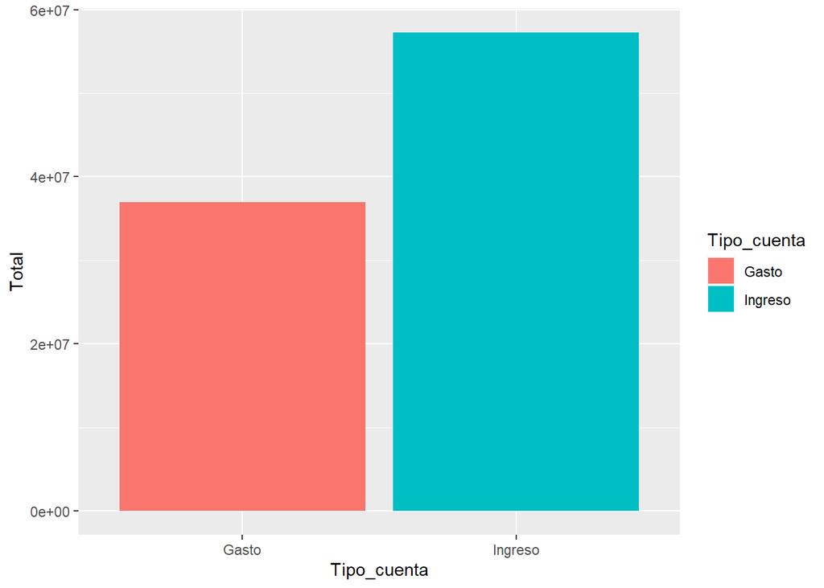

```r
#Debo pasar los importes negativos a positivos para el análisis:
Reporte_graf2 <- mutate(Reporte_brou_aj, Total = abs(Total))

#Genero el gráfico:
ggplot(Reporte_graf2, aes(x = Tipo_cuenta, y = Total, fill = Tipo_cuenta)) +
  geom_bar(stat = "identity") +
  labs(x = "Tipo_cuenta", y = "Total")
```

# Conclusiones

Analizamos un conjunto de datos contables que se encontraban desorganizados y verificamos cuestiones de gestión, como ser la rentabilidad y la estructura de costes.